# Tutorial_4

# 7. Create a function to iterate through and simulate many datatsets

create a function to simulate data These values are from the initial model and data from Sven’s paper, which we created above in section 4, but they can be modified when running the function, which we do below.

```r
index_sim <- function(subj_n = 10, rep_n = 200, bin_n = 6, # these can be changed when calling the function
                      b1c = -4.66, b2c = -3.24, b3c = -2.32, b4c = -1.49, b5c = -1.21, b6c = -0.6,
                      b1i = -4.37, b2i = -3.21, b3i = -2.37, b4i = -2.27, b5i = -3.04, b6i = -2.45, # fixed effects
                      u1c_sd = 1.06, u2c_sd = 1.34, u3c_sd = 0.60, u4c_sd = 0.47, u5c_sd = 0.58, u6c_sd = 0.72,
                      u1i_sd = 1.17, u2i_sd = 1.05, u3i_sd = 0.91, u4i_sd = 1.47, u5i_sd = 1.34, u6i_sd = 0.62, # varying effects
                      cors = cor_mat, # correlations between effects
                      ... # helps the function work with pmap() below
) {
  # set up data structure
  data <- add_random(subj = subj_n, rep = rep_n) |>
    add_within("subj", condition = c("cond1", "cond2")) |>
    add_contrast("condition", "treatment",
      add_cols = TRUE,
      colnames = c("cond")
    ) |>
    add_within("rep", bin = 1:bin_n) |>
    ### create new conditions here that respect the twelve levels b1c, b1i etc.
    mutate(
      con = if_else(condition == "cond1", 1, 0),
      inc = if_else(condition == "cond2", 1, 0)
    ) |>
    mutate(
      bin1 = if_else(bin == 1, 1, 0),
      bin2 = if_else(bin == 2, 1, 0),
      bin3 = if_else(bin == 3, 1, 0),
      bin4 = if_else(bin == 4, 1, 0),
      bin5 = if_else(bin == 5, 1, 0),
      bin6 = if_else(bin == 6, 1, 0)
    ) |>
    # add random effects
    add_ranef("subj",
      u1c = u1c_sd, u2c = u2c_sd, u3c = u3c_sd, u4c = u4c_sd,
      u5c = u5c_sd, u6c = u6c_sd,
      u1i = u1i_sd, u2i = u2i_sd, u3i = u3i_sd, u4i = u4i_sd,
      u5i = u5i_sd, u6i = u6i_sd,
      .cors = cor_mat
    ) |>
    # calculate logit
    mutate(cloglog = (b1c + u1c) * con * bin1 + (b2c + u2c) * con * bin2 +
      (b3c + u3c) * con * bin3 + (b4c + u4c) * con * bin4 +
      (b5c + u5c) * con * bin5 + (b6c + u6c) * con * bin6 +
      (b1i + u1i) * inc * bin1 + (b2i + u2i) * inc * bin2 +
      (b3i + u3i) * inc * bin3 + (b4i + u4i) * inc * bin4 +
      (b5i + u5i) * inc * bin5 + (b6i + u6i) * inc * bin6) |>
    # calculate inverse cloglog
    mutate(prob = clogloglink(cloglog, inverse = TRUE)) |>
    # calculate event
    mutate(event = rbinom(n(), 1, prob)) |>
    group_by(subj, rep, condition) |>
    mutate(
      cumsum = cumsum(event),
      outcomel = event == 1 & cumsum(event) < 2,
      outcomen = if_else(event == 1 & cumsum(event) == 1, 1,
        if_else(cumsum(event) >= 1, NA, 0)
      )
    ) |>
    drop_na(outcomen) |>
    ungroup()

  # glimpse(data) # only use this when testing the code
}
```

Here’s a quick example of how our function works. You can change these parameters and create some different data.

```r
test_sim <- index_sim(subj_n = 10, rep_n = 200) # if you uncomment glimpse above,
# it will let you glimpse the data that's generated. this is useful for checking / testing code purposes.
```

create a function to summarise the simulated data

```r
index_summary <- function(df) {
  df |>
    group_by(subj, condition, bin) |>
    summarise(
      n = n(),
      sum = sum(outcomen),
      mean_outcome = mean(outcomen, na.rm = TRUE),
      sd_outcome = sd(outcomen, na.rm = TRUE),
      sem = (sd_outcome / sqrt(length(unique(rep)))),
      .groups = "drop"
    )
}
```

test it

```r
test_summary <- index_summary(test_sim)
head(test_summary)
```

```
## # A tibble: 6 × 8
##   subj   condition   bin     n   sum mean_outcome sd_outcome     sem
##   <chr>  <fct>     <int> <int> <dbl>        <dbl>      <dbl>   <dbl>
## 1 subj01 cond1         1   200     2       0.0100     0.0997 0.00705
## 2 subj01 cond1         2   198     4       0.0202     0.141  0.0100
## 3 subj01 cond1         3   194    14       0.0722     0.259  0.0186
## 4 subj01 cond1         4   180    30       0.167      0.374  0.0279
## 5 subj01 cond1         5   150    45       0.3        0.460  0.0375
## 6 subj01 cond1         6   105    41       0.390      0.490  0.0478
```

# 8. Simulate data for a range of parameters

vary trial count per condition and effect size, keep pid fixed at N=10. This will take some time, probably hours…go get a beer/coffee. For the purposes of this tutorial, eval is set to false in the below chunks, to save time.

```r
plan(multicore)
x1 <- crossing(
  exp = 1:1000, # number of experiment replicates
  subj_n = 10, # range of subject N
  rep_n = c(100, 200, 400),
  b6i = -2.25,
  b6c = c(-1.94, -1.50, -0.67)
) |>
  mutate(d = pmap(., index_sim)) |>
  mutate(s = map(d, index_summary)) |>
  select(-d)
```

# 9. Summarise the simulated data

```r
sx1 <- x1 |>
  unnest(s) |>
  mutate(
    exp = factor(exp),
    subj_n = factor(subj_n),
    rep_n = factor(rep_n),
    b6c = factor(b6c,
      levels = c("-1.94", "-1.5", "-0.67"),
      labels = c("25%", "50%", "75%")
    ),
    subj = factor(subj),
    bin = factor(bin)
  )
sx1
```

take a look

```r
head(sx1)
tail(sx1)

sx1 |>
  distinct(b6c)
```

save out a file

```r
## save the first simulation
write_csv(sx1, "Tutorial_4_planning/data/sim1/sim1_data.csv")
```

## calculate summary data

read in the file, if it is already computed.

If necessary, read it from the OSF to start with (because it is a large file). This step is only required to be done once. After that, the file will be in your local directory and you can skip this chunk in the future.

```r
## create a relevant folder, if it does not already exist
sim1_output_dir <- here("Tutorial_4_planning/data/sim1/")

if (!dir.exists(here(sim1_output_dir))) {
  dir.create(here(sim1_output_dir))
}

## read in the data from the OSF and store it in a relevant folder, if it does not already exist
sim1_file_name <- here("Tutorial_4_planning/data/sim1/sim1_data.csv")

if (!file.exists(here(sim1_file_name))) {
  osf_retrieve_node("3dbcs") |>
    osf_ls_files(pattern = "Tutorial_4_planning") |>
    osf_ls_files(pattern = "data") |>
    osf_ls_files(pattern = "sim1") |>
    osf_ls_files(pattern = "sim1_data") |>
    osf_download(path = sim1_output_dir)
}
```

read the file from a local folder

```r
sx1 <- read_csv("Tutorial_4_planning/data/sim1/sim1_data.csv") |>
  mutate(
    exp = factor(exp),
    subj_n = factor(subj_n),
    rep_n = factor(rep_n),
    b6c = factor(b6c,
      levels = c("-1.94", "-1.5", "-0.67"),
      labels = c("25%", "50%", "75%")
    ),
    subj = factor(subj),
    bin = factor(bin)
  )
sx1
```

```
## # A tibble: 1,079,143 × 13
##    exp   subj_n rep_n   b6i b6c   subj  condition bin       n   sum mean_outcome
##    <fct> <fct>  <fct> <dbl> <fct> <fct> <chr>     <fct> <dbl> <dbl>        <dbl>
##  1 1     10     100   -2.25 25%   subj… cond1     1       100     3       0.03
##  2 1     10     100   -2.25 25%   subj… cond1     2        97    14       0.144
##  3 1     10     100   -2.25 25%   subj… cond1     3        83    31       0.373
##  4 1     10     100   -2.25 25%   subj… cond1     4        52     7       0.135
##  5 1     10     100   -2.25 25%   subj… cond1     5        45     8       0.178
##  6 1     10     100   -2.25 25%   subj… cond1     6        37     7       0.189
##  7 1     10     100   -2.25 25%   subj… cond2     1       100    12       0.12
##  8 1     10     100   -2.25 25%   subj… cond2     2        88     2       0.0227
##  9 1     10     100   -2.25 25%   subj… cond2     3        86     8       0.0930
## 10 1     10     100   -2.25 25%   subj… cond2     4        78    15       0.192
## # ℹ 1,079,133 more rows
## # ℹ 2 more variables: sd_outcome <dbl>, sem <dbl>
```

at the exp level

```r
sx1_exp <- sx1 |>
  group_by(exp, subj_n, rep_n, b6c, condition, bin) |>
  summarise(
    exp_mean_outcome = mean(mean_outcome, na.rm = TRUE),
    exp_mean_sum = mean(sum, na.rm = TRUE),
    exp_sum = sum(sum),
    n = length(unique(subj)),
    sd = sd(mean_outcome, na.rm = TRUE),
    sem = (sd / sqrt(length(unique(subj)))),
    .groups = "drop"
  )
sx1_exp
```

```
## # A tibble: 108,000 × 12
##    exp   subj_n rep_n b6c   condition bin   exp_mean_outcome exp_mean_sum
##    <fct> <fct>  <fct> <fct> <chr>     <fct>            <dbl>        <dbl>
##  1 1     10     100   25%   cond1     1               0.013           1.3
##  2 1     10     100   25%   cond1     2               0.0513          5
##  3 1     10     100   25%   cond1     3               0.174          15.9
##  4 1     10     100   25%   cond1     4               0.207          16.4
##  5 1     10     100   25%   cond1     5               0.249          15.4
##  6 1     10     100   25%   cond1     6               0.146           5.7
##  7 1     10     100   25%   cond2     1               0.023           2.3
##  8 1     10     100   25%   cond2     2               0.0215          2.1
##  9 1     10     100   25%   cond2     3               0.0988          9.5
## 10 1     10     100   25%   cond2     4               0.0876          7.5
## # ℹ 107,990 more rows
## # ℹ 4 more variables: exp_sum <dbl>, n <int>, sd <dbl>, sem <dbl>
```

at the sim level

```r
sx1_sim <- sx1_exp |>
  group_by(subj_n, rep_n, b6c, condition, bin) |>
  summarise(
    sim_mean_outcome = mean(exp_mean_outcome, na.rm = TRUE),
    sim_mean_sum = mean(exp_mean_sum, na.rm = TRUE),
    sim_sum = mean(exp_sum, na.rm = TRUE),
    n = length(unique(exp)),
    sd = sd(exp_mean_outcome, na.rm = TRUE),
    sem = (sd / sqrt(length(unique(exp)))),
    .groups = "drop"
  )
sx1_sim
```

```
## # A tibble: 108 × 11
##    subj_n rep_n b6c   condition bin   sim_mean_outcome sim_mean_sum sim_sum
##    <fct>  <fct> <fct> <chr>     <fct>            <dbl>        <dbl>   <dbl>
##  1 10     100   25%   cond1     1               0.0161         1.61    16.1
##  2 10     100   25%   cond1     2               0.0797         7.81    78.1
##  3 10     100   25%   cond1     3               0.108          9.67    96.7
##  4 10     100   25%   cond1     4               0.217         17.3    173.
##  5 10     100   25%   cond1     5               0.282         17.8    178.
##  6 10     100   25%   cond1     6               0.162          7.18    71.8
##  7 10     100   25%   cond2     1               0.0232         2.32    23.2
##  8 10     100   25%   cond2     2               0.0644         6.27    62.7
##  9 10     100   25%   cond2     3               0.123         11.1    111.
## 10 10     100   25%   cond2     4               0.184         14.3    143.
## # ℹ 98 more rows
## # ℹ 3 more variables: n <int>, sd <dbl>, sem <dbl>
```

a quick plot of the data

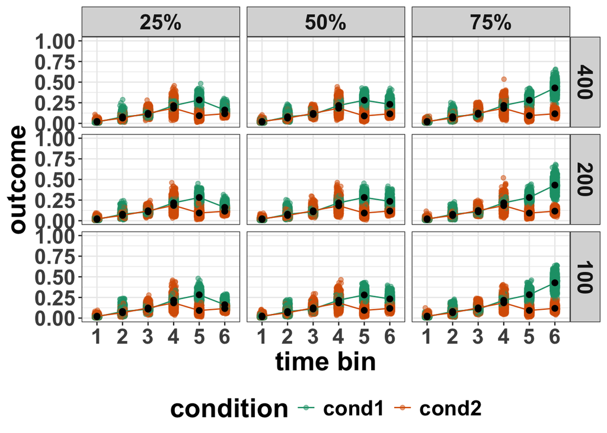

```r
p9.1 <- ggplot(
  sx1_sim,
  aes(
    x = bin, y = sim_mean_outcome,
    colour = condition
  )
) +
  geom_jitter(
    data = sx1_exp, aes(y = exp_mean_outcome),
    alpha = 0.5, width = 0.1, height = 0
  ) +
  geom_line(aes(group = condition)) +
  geom_point(size = 2, colour = "black") +
  geom_errorbar(aes(ymin = sim_mean_outcome - sem * 1.96, ymax = sim_mean_outcome + sem * 1.96),
    width = .2, colour = "black"
  ) +
  scale_colour_brewer(palette = "Dark2") +
  scale_y_continuous(limits = c(0, 1), breaks = seq(0, 1, 0.25)) +
  labs(
    x = "time bin",
    y = "outcome"
  ) +
  facet_grid(fct_rev(rep_n) ~ b6c)
p9.1
```

```r
ggsave("Tutorial_4_planning/figures/sim1/sim_violin.jpeg",
  width = 10, height = 8, dpi = 800
)
```

ok, look at some values in bin 6

at the exp level

```r
sx1_exp_check <- sx1_exp |>
  filter(bin %in% c(6)) |>
  select(exp, rep_n, b6c, condition, bin, exp_mean_outcome) |>
  pivot_wider(
    names_from = "condition",
    values_from = "exp_mean_outcome"
  ) |>
  group_by(exp, rep_n, b6c, bin) |>
  mutate(ratio = cond2 / cond1)
head(sx1_exp_check)
```

```
## # A tibble: 6 × 7
## # Groups:   exp, rep_n, b6c, bin [6]
##   exp   rep_n b6c   bin   cond1  cond2 ratio
##   <fct> <fct> <fct> <fct> <dbl>  <dbl> <dbl>
## 1 1     100   25%   6     0.146 0.116  0.797
## 2 1     100   50%   6     0.268 0.118  0.442
## 3 1     100   75%   6     0.454 0.117  0.259
## 4 1     200   25%   6     0.170 0.147  0.862
## 5 1     200   50%   6     0.225 0.106  0.473
## 6 1     200   75%   6     0.375 0.0940 0.250
```

and at the sim level

```r
sx1_sim_check <- sx1_exp_check |>
  group_by(rep_n, b6c, bin) |>
  summarise(
    sim_ratio = mean(ratio),
    sim_sd = sd(ratio),
    sim_sem = sim_sd / sqrt(1000),
    .groups = "drop"
  )
head(sx1_sim_check)
```

```
## # A tibble: 6 × 6
##   rep_n b6c   bin   sim_ratio sim_sd sim_sem
##   <fct> <fct> <fct>     <dbl>  <dbl>   <dbl>
## 1 100   25%   6         0.756 0.264  0.00834
## 2 100   50%   6         0.527 0.167  0.00529
## 3 100   75%   6         0.282 0.0798 0.00252
## 4 200   25%   6         0.742 0.221  0.00700
## 5 200   50%   6         0.519 0.148  0.00469
## 6 200   75%   6         0.275 0.0724 0.00229
```

plot ratio values

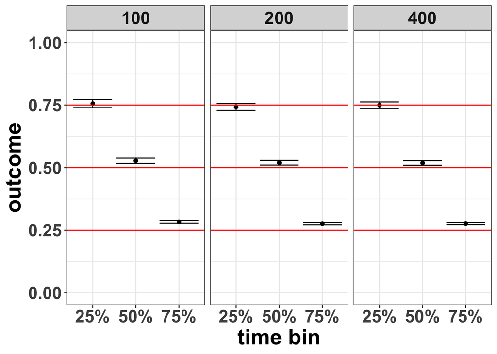

```r
p9.2 <- ggplot(
  sx1_sim_check,
  aes(x = b6c, y = sim_ratio)
) +
  geom_point(size = 1.5) +
  geom_errorbar(aes(ymin = sim_ratio - sim_sem * 1.96, ymax = sim_ratio + sim_sem * 1.96)) +
  geom_hline(yintercept = c(0.25, 0.5, 0.75), colour = "red") +
  scale_colour_brewer(palette = "Dark2") +
  scale_y_continuous(limits = c(0, 1), breaks = seq(0, 1, 0.25)) +
  labs(
    x = "time bin",
    y = "outcome"
  ) +
  facet_wrap(~rep_n)
p9.2
```

# 10. calculate power / precision

basic idea - calculate the difference score in hazard between con and inc per bin and then report how many lower bound 95% quantile intervals exclude zero? This of course is not a model-based estimate. But we think it should give a reasonable guide to what we might expect.

## calculate difference scores

at the exp level

```r
sx1_diff_exp <- sx1 |>
  pivot_wider(
    id_cols = c(exp, subj_n, rep_n, b6c, subj, bin),
    names_from = "condition",
    values_from = "mean_outcome"
  ) |>
  mutate(diff = cond1 - cond2) |>
  group_by(exp, subj_n, rep_n, b6c, bin) |>
  summarise(
    exp_mean_diff = mean(diff, na.rm = TRUE),
    exp_sd = sd(diff, na.rm = TRUE),
    n = n(), # n here is the total trials per condition per pid
    exp_sem = (exp_sd / sqrt(n)),
    exp_ci = 1.96 * exp_sem,
    exp_dz = exp_mean_diff / exp_sd,
    .groups = "drop"
  )
head(sx1_diff_exp)
```

```
## # A tibble: 6 × 11
##   exp   subj_n rep_n b6c   bin   exp_mean_diff exp_sd     n exp_sem exp_ci
##   <fct> <fct>  <fct> <fct> <fct>         <dbl>  <dbl> <int>   <dbl>  <dbl>
## 1 1     10     100   25%   1           -0.01   0.0406    10  0.0128 0.0251
## 2 1     10     100   25%   2            0.0297 0.0504    10  0.0159 0.0312
## 3 1     10     100   25%   3            0.0755 0.152     10  0.0482 0.0944
## 4 1     10     100   25%   4            0.120  0.147     10  0.0466 0.0914
## 5 1     10     100   25%   5            0.0673 0.262     10  0.0828 0.162
## 6 1     10     100   25%   6            0.0296 0.124     10  0.0391 0.0767
## # ℹ 1 more variable: exp_dz <dbl>
```

```r
tail(sx1_diff_exp)
```

```
## # A tibble: 6 × 11
##   exp   subj_n rep_n b6c   bin   exp_mean_diff exp_sd     n exp_sem exp_ci
##   <fct> <fct>  <fct> <fct> <fct>         <dbl>  <dbl> <int>   <dbl>  <dbl>
## 1 1000  10     400   75%   1           0.00475 0.0254    10 0.00803 0.0157
## 2 1000  10     400   75%   2          -0.0171  0.119     10 0.0377  0.0739
## 3 1000  10     400   75%   3          -0.0714  0.131     10 0.0413  0.0809
## 4 1000  10     400   75%   4           0.0297  0.200     10 0.0632  0.124
## 5 1000  10     400   75%   5           0.103   0.248     10 0.0786  0.154
## 6 1000  10     400   75%   6           0.334   0.187     10 0.0592  0.116
## # ℹ 1 more variable: exp_dz <dbl>
```

at the group/sim level

```r
sx1_diff_sim <- sx1_diff_exp |>
  group_by(subj_n, rep_n, b6c, bin) |>
  summarise(
    mean_diff = mean(exp_mean_diff, na.rm = TRUE),
    sd = sd(exp_mean_diff, na.rm = TRUE),
    n = n(),
    sem = (sd / sqrt((n))),
    ci = 1.96 * sem
  )
sx1_diff_sim
```

```
## # A tibble: 54 × 9
## # Groups:   subj_n, rep_n, b6c [9]
##    subj_n rep_n b6c   bin   mean_diff     sd     n      sem       ci
##    <fct>  <fct> <fct> <fct>     <dbl>  <dbl> <int>    <dbl>    <dbl>
##  1 10     100   25%   1      -0.00711 0.0136  1000 0.000431 0.000845
##  2 10     100   25%   2       0.0153  0.0435  1000 0.00138  0.00270
##  3 10     100   25%   3      -0.0145  0.0401  1000 0.00127  0.00249
##  4 10     100   25%   4       0.0326  0.0721  1000 0.00228  0.00447
##  5 10     100   25%   5       0.190   0.0588  1000 0.00186  0.00365
##  6 10     100   25%   6       0.0459  0.0463  1000 0.00146  0.00287
##  7 10     100   50%   1      -0.00897 0.0152  1000 0.000482 0.000945
##  8 10     100   50%   2       0.0155  0.0395  1000 0.00125  0.00245
##  9 10     100   50%   3      -0.0133  0.0399  1000 0.00126  0.00247
## 10 10     100   50%   4       0.0331  0.0744  1000 0.00235  0.00461
## # ℹ 44 more rows
```

## plot

violin

diff in original units

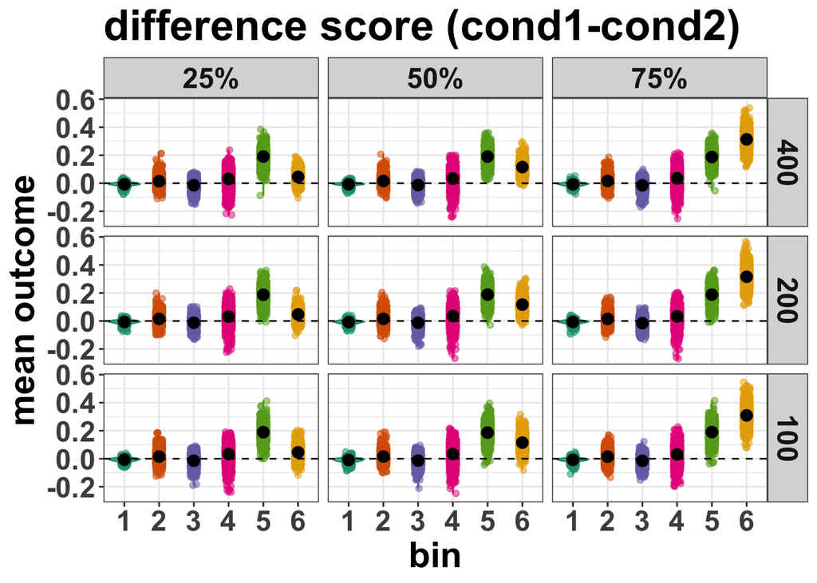

```r
p10.1 <- ggplot(sx1_diff_exp, aes(
  x = bin, y = exp_mean_diff,
  colour = bin, fill = bin
)) +
  geom_jitter(alpha = 0.5, width = 0.1) +
  geom_violin(alpha = 0.7) +
  geom_point(
    data = sx1_diff_sim,
    aes(y = mean_diff), size = 3, position = pd2, colour = "black"
  ) +
  geom_errorbar(
    data = sx1_diff_sim,
    aes(y = mean_diff, ymin = mean_diff - ci, ymax = mean_diff + ci),
    width = .2, position = pd2, colour = "black"
  ) +
  geom_hline(yintercept = 0, colour = "black", linetype = "dashed") +
  scale_fill_brewer(palette = "Dark2") +
  scale_colour_brewer(palette = "Dark2") +
  theme(legend.position = "none") +
  ylab("mean outcome") +
  ggtitle("difference score (cond1-cond2)") +
  facet_grid(fct_rev(rep_n) ~ b6c)
p10.1
```

```r
ggsave("Tutorial_4_planning/figures/sim1/sim_diffs.jpeg",
  width = 10, height = 8, dpi = 800
)
```

plot each exp’s difference score and associated 95% interval

create some factors and new variables

```r
sx1_diff_exp_2 <- sx1_diff_exp |>
  group_by(exp, subj_n, rep_n, b6c, bin) |>
  mutate(
    lower = exp_mean_diff - exp_ci,
    upper = exp_mean_diff + exp_ci,
    above_zero = if_else(lower > 0, "yes", "no"),
    above_zero = factor(above_zero, levels = c("no", "yes"))
  )
sx1_diff_exp_2
```

```
## # A tibble: 54,000 × 14
## # Groups:   exp, subj_n, rep_n, b6c, bin [54,000]
##    exp   subj_n rep_n b6c   bin   exp_mean_diff exp_sd     n exp_sem exp_ci
##    <fct> <fct>  <fct> <fct> <fct>         <dbl>  <dbl> <int>   <dbl>  <dbl>
##  1 1     10     100   25%   1           -0.01   0.0406    10 0.0128  0.0251
##  2 1     10     100   25%   2            0.0297 0.0504    10 0.0159  0.0312
##  3 1     10     100   25%   3            0.0755 0.152     10 0.0482  0.0944
##  4 1     10     100   25%   4            0.120  0.147     10 0.0466  0.0914
##  5 1     10     100   25%   5            0.0673 0.262     10 0.0828  0.162
##  6 1     10     100   25%   6            0.0296 0.124     10 0.0391  0.0767
##  7 1     10     100   50%   1            0.008  0.0181    10 0.00573 0.0112
##  8 1     10     100   50%   2           -0.0375 0.0487    10 0.0154  0.0302
##  9 1     10     100   50%   3           -0.0220 0.116     10 0.0367  0.0720
## 10 1     10     100   50%   4           -0.115  0.336     10 0.106   0.209
## # ℹ 53,990 more rows
## # ℹ 4 more variables: exp_dz <dbl>, lower <dbl>, upper <dbl>, above_zero <fct>
```

calculate “power” in a quick and dirty way based on 95% CI

```r
power_x1 <- sx1_diff_exp_2 |>
  group_by(subj_n, rep_n, b6c, bin) |>
  mutate(check = ifelse(lower > 0, 1, 0)) |>
  summarise(power = mean(check, na.rm = TRUE)) |>
  filter(bin %in% c(6))
power_x1
```

```
## # A tibble: 9 × 5
## # Groups:   subj_n, rep_n, b6c [9]
##   subj_n rep_n b6c   bin   power
##   <fct>  <fct> <fct> <fct> <dbl>
## 1 10     100   25%   6     0.202
## 2 10     100   50%   6     0.608
## 3 10     100   75%   6     0.993
## 4 10     200   25%   6     0.21
## 5 10     200   50%   6     0.675
## 6 10     200   75%   6     0.999
## 7 10     400   25%   6     0.216
## 8 10     400   50%   6     0.693
## 9 10     400   75%   6     0.998
```

plot power

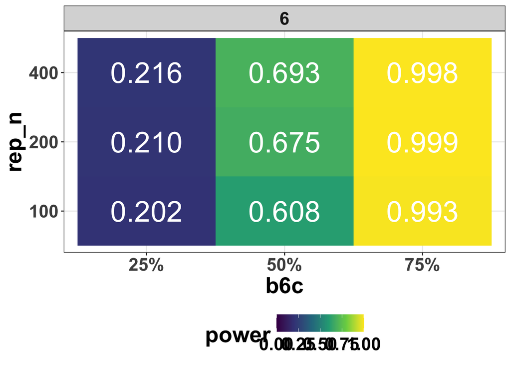

```r
p10.2 <- ggplot(power_x1, aes(x = b6c, y = rep_n, fill = power)) +
  geom_tile() +
  geom_text(aes(label = sprintf("%.3f", power)), color = "white", size = 10) +
  scale_fill_viridis_c(limits = c(0, 1)) +
  facet_wrap(~bin) +
  labs(y = "rep_n", x = "b6c")
p10.2
```

```r
#

ggsave("Tutorial_4_planning/figures/sim1/power.jpeg",
  width = 10, height = 6, dpi = 800
)
```

join power to the df

```r
sx1_diff_power <- sx1_diff_exp_2 |>
  filter(bin %in% c(6)) |>
  inner_join(power_x1, by = c("subj_n", "rep_n", "b6c", "bin")) |>
  mutate(power = round(power * 100, 2))
head(sx1_diff_power)
```

```
## # A tibble: 6 × 15
## # Groups:   exp, subj_n, rep_n, b6c, bin [6]
##   exp   subj_n rep_n b6c   bin   exp_mean_diff exp_sd     n exp_sem exp_ci
##   <fct> <fct>  <fct> <fct> <fct>         <dbl>  <dbl> <int>   <dbl>  <dbl>
## 1 1     10     100   25%   6            0.0296  0.124    10  0.0391 0.0767
## 2 1     10     100   50%   6            0.150   0.136    10  0.0431 0.0846
## 3 1     10     100   75%   6            0.337   0.224    10  0.0710 0.139
## 4 1     10     200   25%   6            0.0234  0.166    10  0.0526 0.103
## 5 1     10     200   50%   6            0.118   0.230    10  0.0727 0.143
## 6 1     10     200   75%   6            0.281   0.259    10  0.0820 0.161
## # ℹ 5 more variables: exp_dz <dbl>, lower <dbl>, upper <dbl>, above_zero <fct>,
## #   power <dbl>
```

plot

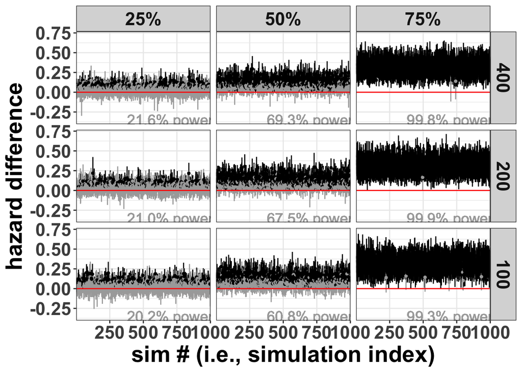

```r
p10.3 <- sx1_diff_power |>
  ggplot(aes(x = exp, y = exp_mean_diff, ymin = lower, ymax = upper)) +
  geom_pointrange(fatten = 1 / 2, aes(colour = above_zero)) +
  geom_hline(yintercept = 0, colour = "red") +
  scale_colour_manual(values = c("darkgrey", "black")) +
  geom_text(aes(x = 700, y = -0.35, label = sprintf("%.1f%s", power, "% power")),
    color = "darkgrey", size = 5
  ) +
  theme(legend.position = "none") +
  labs(
    x = "sim # (i.e., simulation index)",
    y = "hazard difference"
  ) +
  scale_x_discrete(breaks = c(250, 500, 750, 1000)) +
  facet_grid(fct_rev(rep_n) ~ b6c)
p10.3
```

```r
ggsave("Tutorial_4_planning/figures/sim1/bin6_diffs.jpeg",
  width = 10, height = 8, dpi = 800
)
```

plot power as a bar plot

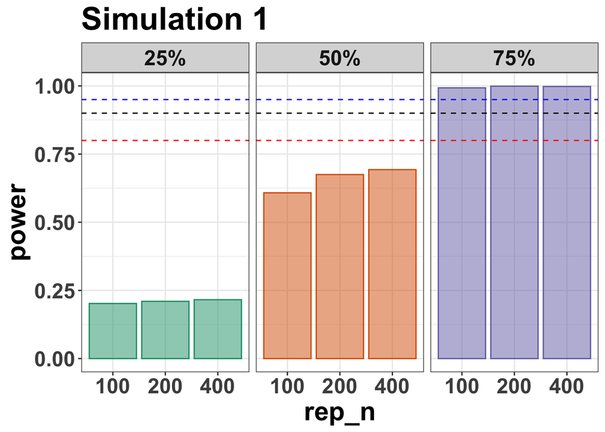

```r
p10.4 <- ggplot(power_x1, aes(
  x = rep_n, y = power,
  colour = b6c, fill = b6c
)) +
  geom_col(alpha = 0.5) +
  geom_hline(yintercept = 0.8, colour = "red", linetype = "dashed") +
  geom_hline(yintercept = 0.9, colour = "black", linetype = "dashed") +
  geom_hline(yintercept = 0.95, colour = "blue", linetype = "dashed") +
  scale_colour_brewer(palette = "Dark2") +
  scale_fill_brewer(palette = "Dark2") +
  labs(title = "Simulation 1") +
  theme(legend.position = "none") +
  facet_wrap(~b6c, nrow = 1)
p10.4
```

```r
ggsave("Tutorial_4_planning/figures/sim1/bin6_power_col.jpeg",
  width = 8, height = 6, dpi = 800
)
```

ok, on the basis of this analysis, we might make the following conclusions:

- effects of con vs inc that are as large as previously reported by Panis & Schimdt (2016) would be easy to detect with 100 trials and 10 pids. And probably less data than that also.
- Across all effect sizes, there is no benefit of adding more than 200 trials per condition.
- Within the context of these absolute hazard values, somewhere between a 50% reduction and a 75% reduction would give you 80% power to detect an effect, should it exist. e.g., a 75% reduction is nearly 100% power. A 50% reduction is 70% power. So maybe a 60% reduction would give 80% power, with N=10 and trial =200. We could run more sims to figure that out.
- Other analyses to run - how many individual pids per exp show a clear effect of con vs inc in bin 6? This would be useful to know if we used the small-N design logic and the individual as the unit of replication.

# 11. Run a follow-up simulation

Let’s try a 50%, 60% and 70% reduction across N=10, 15 and 20.

let’s check effect sizes quickly.

```r
bin6_v2 <- tibble(
  effect_id = 1:3,
  inc = rep(0.1, times = 3),
  ratio = c(0.3, 0.4, 0.5),
  con = inc / ratio,
  inc_clog = clogloglink(inc),
  con_clog = clogloglink(con)
)
bin6_v2
```

```
## # A tibble: 3 × 6
##   effect_id   inc ratio   con inc_clog con_clog
##       <int> <dbl> <dbl> <dbl>    <dbl>    <dbl>
## 1         1   0.1   0.3 0.333    -2.25   -0.903
## 2         2   0.1   0.4 0.25     -2.25   -1.25
## 3         3   0.1   0.5 0.2      -2.25   -1.50
```

```r
# effect_id   inc ratio   con inc_clog con_clog
#       <int> <dbl> <dbl> <dbl>    <dbl>    <dbl>
# 1         1   0.1   0.3 0.333    -2.25   -0.903
# 2         2   0.1   0.4 0.25     -2.25   -1.25
# 3         3   0.1   0.5 0.2      -2.25   -1.50
```

## run the sim

vary effect size and pid. Again, as before, this will take some time, probably hours…go get another beer/coffee. And again, eval is set to FALSE, to save time for the tutorial.

```r
plan(multicore)
x2 <- crossing(
  exp = 1:1000, # number of experiment replicates
  subj_n = c(10, 15, 20), # range of subject N
  rep_n = 200,
  b6i = -2.25,
  b6c = c(-0.90, -1.25, -1.50)
) |>
  mutate(d = pmap(., index_sim)) |>
  mutate(s = map(d, index_summary)) |>
  select(-d)
```

## summarise the simulated data

```r
sx2 <- x2 |>
  unnest(s) |>
  mutate(
    exp = factor(exp),
    subj_n = factor(subj_n),
    rep_n = factor(rep_n),
    b6c = factor(b6c,
      levels = c("-1.5", "-1.25", "-0.9"),
      labels = c("50%", "60%", "70%")
    ),
    subj = factor(subj),
    bin = factor(bin)
  )
sx2
```

take a look

```r
head(sx2)
tail(sx2)

sx2 |>
  distinct(b6c)
```

save out a file

```r
## save the first simulation
write_csv(sx2, "Tutorial_4_planning/data/sim2/sim2_data.csv")
```

## calculate summary data

read in the file, if it is already computed.

If necessary, read it from the OSF to start with (because it is a large file). This step is only required to be done once. After that, the file will be in your local directory and you can skip this chunk in the future. To do so, set eval=TRUE in the chunk below, then re-set to FALSE once the data have been downloaded.

```r
## create a relevant folder, if it does not already exist
sim2_output_dir <- here("Tutorial_4_planning/data/sim2/")

if (!dir.exists(here(sim2_output_dir))) {
  dir.create(here(sim2_output_dir))
}

## read in the data from the OSF and store it in a relevant folder, if it does not already exist
sim2_file_name <- here("Tutorial_4_planning/data/sim2/sim2_data.csv")

if (!file.exists(here(sim2_file_name))) {
  osf_retrieve_node("3dbcs") |>
    osf_ls_files(pattern = "Tutorial_4_planning") |>
    osf_ls_files(pattern = "data") |>
    osf_ls_files(pattern = "sim2") |>
    osf_ls_files(pattern = "sim2_data") |>
    osf_download(path = sim2_output_dir)
}
```

read the file from a local folder

```r
sx2 <- read_csv("Tutorial_4_planning/data/sim2/sim2_data.csv") |>
  mutate(
    exp = factor(exp),
    subj_n = factor(subj_n),
    rep_n = factor(rep_n),
    b6c = factor(b6c,
      levels = c("-1.5", "-1.25", "-0.9"),
      labels = c("50%", "60%", "70%")
    ),
    subj = factor(subj),
    bin = factor(bin)
  )
sx2
```

```
## # A tibble: 1,618,687 × 13
##    exp   subj_n rep_n   b6i b6c   subj  condition bin       n   sum mean_outcome
##    <fct> <fct>  <fct> <dbl> <fct> <fct> <chr>     <fct> <dbl> <dbl>        <dbl>
##  1 1     10     200   -2.25 50%   subj… cond1     1       200     1       0.005
##  2 1     10     200   -2.25 50%   subj… cond1     2       199     6       0.0302
##  3 1     10     200   -2.25 50%   subj… cond1     3       193     7       0.0363
##  4 1     10     200   -2.25 50%   subj… cond1     4       186    16       0.0860
##  5 1     10     200   -2.25 50%   subj… cond1     5       170    30       0.176
##  6 1     10     200   -2.25 50%   subj… cond1     6       140    26       0.186
##  7 1     10     200   -2.25 50%   subj… cond2     1       200     1       0.005
##  8 1     10     200   -2.25 50%   subj… cond2     2       199     8       0.0402
##  9 1     10     200   -2.25 50%   subj… cond2     3       191    14       0.0733
## 10 1     10     200   -2.25 50%   subj… cond2     4       177     2       0.0113
## # ℹ 1,618,677 more rows
## # ℹ 2 more variables: sd_outcome <dbl>, sem <dbl>
```

at the exp level

```r
sx2_exp <- sx2 |>
  group_by(exp, subj_n, rep_n, b6c, condition, bin) |>
  summarise(
    exp_mean_outcome = mean(mean_outcome, na.rm = TRUE),
    exp_mean_sum = mean(sum, na.rm = TRUE),
    exp_sum = sum(sum),
    n = length(unique(subj)),
    sd = sd(mean_outcome, na.rm = TRUE),
    sem = (sd / sqrt(length(unique(subj)))),
    .groups = "drop"
  )
sx2_exp
```

```
## # A tibble: 108,000 × 12
##    exp   subj_n rep_n b6c   condition bin   exp_mean_outcome exp_mean_sum
##    <fct> <fct>  <fct> <fct> <chr>     <fct>            <dbl>        <dbl>
##  1 1     10     200   50%   cond1     1               0.014           2.8
##  2 1     10     200   50%   cond1     2               0.0449          8.8
##  3 1     10     200   50%   cond1     3               0.0550         10.3
##  4 1     10     200   50%   cond1     4               0.200          35.4
##  5 1     10     200   50%   cond1     5               0.305          43
##  6 1     10     200   50%   cond1     6               0.306          28.9
##  7 1     10     200   50%   cond2     1               0.013           2.6
##  8 1     10     200   50%   cond2     2               0.0410          8.1
##  9 1     10     200   50%   cond2     3               0.123          22.3
## 10 1     10     200   50%   cond2     4               0.219          31.7
## # ℹ 107,990 more rows
## # ℹ 4 more variables: exp_sum <dbl>, n <int>, sd <dbl>, sem <dbl>
```

at the sim level

```r
sx2_sim <- sx2_exp |>
  group_by(subj_n, rep_n, b6c, condition, bin) |>
  summarise(
    sim_mean_outcome = mean(exp_mean_outcome, na.rm = TRUE),
    sim_mean_sum = mean(exp_mean_sum, na.rm = TRUE),
    sim_sum = mean(exp_sum, na.rm = TRUE),
    n = length(unique(exp)),
    sd = sd(exp_mean_outcome, na.rm = TRUE),
    sem = (sd / sqrt(length(unique(exp)))),
    .groups = "drop"
  )
sx2_sim
```

```
## # A tibble: 108 × 11
##    subj_n rep_n b6c   condition bin   sim_mean_outcome sim_mean_sum sim_sum
##    <fct>  <fct> <fct> <chr>     <fct>            <dbl>        <dbl>   <dbl>
##  1 10     200   50%   cond1     1               0.0162         3.25    32.5
##  2 10     200   50%   cond1     2               0.0776        15.2    152.
##  3 10     200   50%   cond1     3               0.108         19.4    194.
##  4 10     200   50%   cond1     4               0.218         35.0    350.
##  5 10     200   50%   cond1     5               0.285         36.0    360.
##  6 10     200   50%   cond1     6               0.236         20.9    209.
##  7 10     200   50%   cond2     1               0.0235         4.70    47.0
##  8 10     200   50%   cond2     2               0.0650        12.6    126.
##  9 10     200   50%   cond2     3               0.124         22.3    223.
## 10 10     200   50%   cond2     4               0.186         28.8    288.
## # ℹ 98 more rows
## # ℹ 3 more variables: n <int>, sd <dbl>, sem <dbl>
```

a quick plot of the data

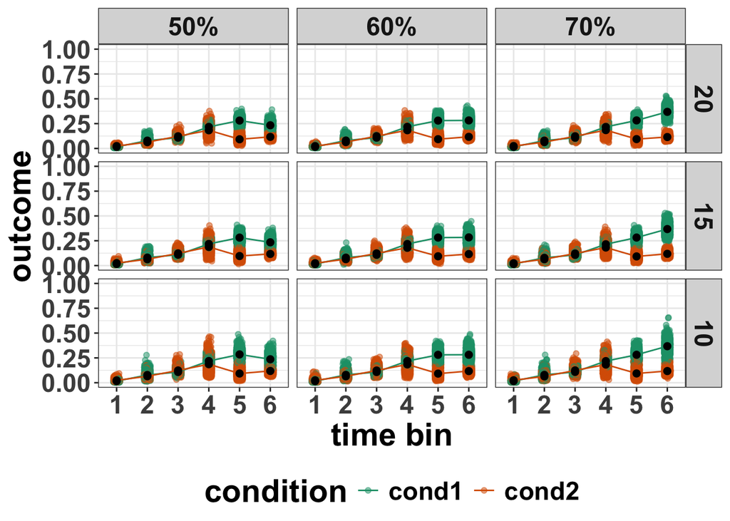

```r
p11.1 <- ggplot(
  sx2_sim,
  aes(
    x = bin, y = sim_mean_outcome,
    colour = condition
  )
) +
  geom_jitter(
    data = sx2_exp, aes(y = exp_mean_outcome),
    alpha = 0.5, width = 0.1, height = 0
  ) +
  geom_line(aes(group = condition)) +
  geom_point(size = 2, colour = "black") +
  geom_errorbar(aes(ymin = sim_mean_outcome - sem * 1.96, ymax = sim_mean_outcome + sem * 1.96),
    width = .2, colour = "black"
  ) +
  scale_colour_brewer(palette = "Dark2") +
  scale_y_continuous(limits = c(0, 1), breaks = seq(0, 1, 0.25)) +
  labs(
    x = "time bin",
    y = "outcome"
  ) +
  facet_grid(fct_rev(subj_n) ~ b6c)
p11.1
```

```r
ggsave("Tutorial_4_planning/figures/sim2/sim_violin.jpeg",
  width = 10, height = 8, dpi = 800
)
```

ok, look at some values in bin 6

at the exp level

```r
sx2_exp_check <- sx2_exp |>
  filter(bin %in% c(6)) |>
  select(exp, subj_n, b6c, condition, bin, exp_mean_outcome) |>
  pivot_wider(
    names_from = "condition",
    values_from = "exp_mean_outcome"
  ) |>
  group_by(exp, subj_n, b6c, bin) |>
  mutate(ratio = cond2 / cond1)
head(sx2_exp_check)
```

```
## # A tibble: 6 × 7
## # Groups:   exp, subj_n, b6c, bin [6]
##   exp   subj_n b6c   bin   cond1 cond2 ratio
##   <fct> <fct>  <fct> <fct> <dbl> <dbl> <dbl>
## 1 1     10     50%   6     0.306 0.143 0.466
## 2 1     10     60%   6     0.295 0.119 0.403
## 3 1     10     70%   6     0.399 0.104 0.261
## 4 1     15     50%   6     0.185 0.113 0.613
## 5 1     15     60%   6     0.234 0.129 0.550
## 6 1     15     70%   6     0.327 0.123 0.376
```

and at the sim level

```r
sx2_sim_check <- sx2_exp_check |>
  group_by(subj_n, b6c, bin) |>
  summarise(
    sim_ratio = mean(ratio),
    sim_sd = sd(ratio),
    sim_sem = sim_sd / sqrt(1000),
    .groups = "drop"
  )
head(sx2_sim_check)
```

```
## # A tibble: 6 × 6
##   subj_n b6c   bin   sim_ratio sim_sd sim_sem
##   <fct>  <fct> <fct>     <dbl>  <dbl>   <dbl>
## 1 10     50%   6         0.517 0.142  0.00450
## 2 10     60%   6         0.429 0.118  0.00373
## 3 10     70%   6         0.328 0.0888 0.00281
## 4 15     50%   6         0.513 0.125  0.00395
## 5 15     60%   6         0.417 0.0968 0.00306
## 6 15     70%   6         0.327 0.0722 0.00228
```

plot ratio values

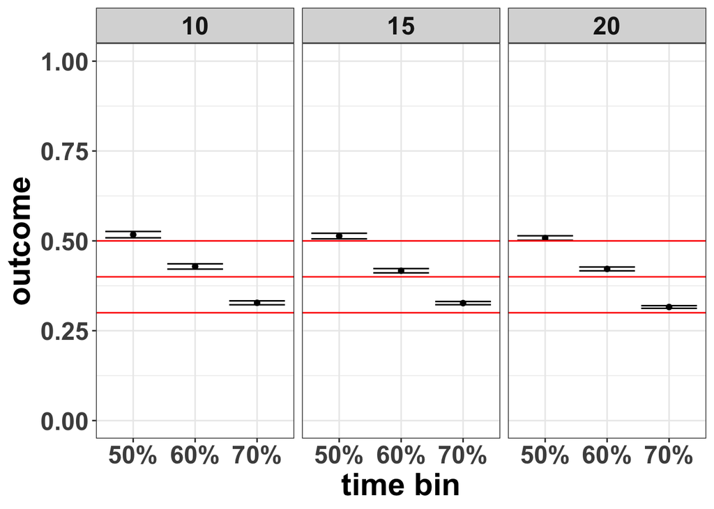

```r
p11.2 <- ggplot(
  sx2_sim_check,
  aes(x = b6c, y = sim_ratio)
) +
  geom_point(size = 1.5) +
  geom_errorbar(aes(ymin = sim_ratio - sim_sem * 1.96, ymax = sim_ratio + sim_sem * 1.96)) +
  geom_hline(yintercept = c(0.3, 0.4, 0.5), colour = "red") +
  scale_colour_brewer(palette = "Dark2") +
  scale_y_continuous(limits = c(0, 1), breaks = seq(0, 1, 0.25)) +
  labs(
    x = "time bin",
    y = "outcome"
  ) +
  facet_wrap(~subj_n)
p11.2
```

## calculate power / precision

Same basic idea as in Simulation 1.

## calculate difference scores

at the exp level

```r
sx2_diff_exp <- sx2 |>
  pivot_wider(
    id_cols = c(exp, subj_n, rep_n, b6c, subj, bin),
    names_from = "condition",
    values_from = "mean_outcome"
  ) |>
  mutate(diff = cond1 - cond2) |>
  group_by(exp, subj_n, rep_n, b6c, bin) |>
  summarise(
    exp_mean_diff = mean(diff, na.rm = TRUE),
    exp_sd = sd(diff, na.rm = TRUE),
    n = n(), # n here is the total trials per condition per pid
    exp_sem = (exp_sd / sqrt(n)),
    exp_ci = 1.96 * exp_sem,
    exp_dz = exp_mean_diff / exp_sd,
    .groups = "drop"
  )
head(sx2_diff_exp)
```

```
## # A tibble: 6 × 11
##   exp   subj_n rep_n b6c   bin   exp_mean_diff exp_sd     n exp_sem exp_ci
##   <fct> <fct>  <fct> <fct> <fct>         <dbl>  <dbl> <int>   <dbl>  <dbl>
## 1 1     10     200   50%   1           0.00100 0.0165    10 0.00521 0.0102
## 2 1     10     200   50%   2           0.00386 0.0777    10 0.0246  0.0482
## 3 1     10     200   50%   3          -0.0676  0.108     10 0.0342  0.0671
## 4 1     10     200   50%   4          -0.0189  0.258     10 0.0816  0.160
## 5 1     10     200   50%   5           0.221   0.184     10 0.0580  0.114
## 6 1     10     200   50%   6           0.163   0.176     10 0.0558  0.109
## # ℹ 1 more variable: exp_dz <dbl>
```

```r
tail(sx2_diff_exp)
```

```
## # A tibble: 6 × 11
##   exp   subj_n rep_n b6c   bin   exp_mean_diff exp_sd     n exp_sem exp_ci
##   <fct> <fct>  <fct> <fct> <fct>         <dbl>  <dbl> <int>   <dbl>  <dbl>
## 1 1000  20     200   70%   1          -0.00675 0.0369    20 0.00825 0.0162
## 2 1000  20     200   70%   2          -0.0174  0.0696    20 0.0156  0.0305
## 3 1000  20     200   70%   3           0.0574  0.0611    20 0.0137  0.0268
## 4 1000  20     200   70%   4           0.0291  0.231     20 0.0517  0.101
## 5 1000  20     200   70%   5           0.180   0.131     20 0.0294  0.0576
## 6 1000  20     200   70%   6           0.277   0.184     20 0.0413  0.0809
## # ℹ 1 more variable: exp_dz <dbl>
```

at the group/sim level

```r
sx2_diff_sim <- sx2_diff_exp |>
  group_by(subj_n, rep_n, b6c, bin) |>
  summarise(
    mean_diff = mean(exp_mean_diff, na.rm = TRUE),
    sd = sd(exp_mean_diff, na.rm = TRUE),
    n = n(),
    sem = (sd / sqrt((n))),
    ci = 1.96 * sem
  )
sx2_diff_sim
```

```
## # A tibble: 54 × 9
## # Groups:   subj_n, rep_n, b6c [9]
##    subj_n rep_n b6c   bin   mean_diff     sd     n      sem       ci
##    <fct>  <fct> <fct> <fct>     <dbl>  <dbl> <int>    <dbl>    <dbl>
##  1 10     200   50%   1      -0.00728 0.0125  1000 0.000394 0.000772
##  2 10     200   50%   2       0.0126  0.0408  1000 0.00129  0.00253
##  3 10     200   50%   3      -0.0157  0.0386  1000 0.00122  0.00239
##  4 10     200   50%   4       0.0320  0.0734  1000 0.00232  0.00455
##  5 10     200   50%   5       0.192   0.0572  1000 0.00181  0.00355
##  6 10     200   50%   6       0.118   0.0496  1000 0.00157  0.00308
##  7 10     200   60%   1      -0.00780 0.0139  1000 0.000439 0.000861
##  8 10     200   60%   2       0.0138  0.0391  1000 0.00124  0.00242
##  9 10     200   60%   3      -0.0147  0.0388  1000 0.00123  0.00240
## 10 10     200   60%   4       0.0335  0.0685  1000 0.00217  0.00424
## # ℹ 44 more rows
```

## plot

violin

diff in original units

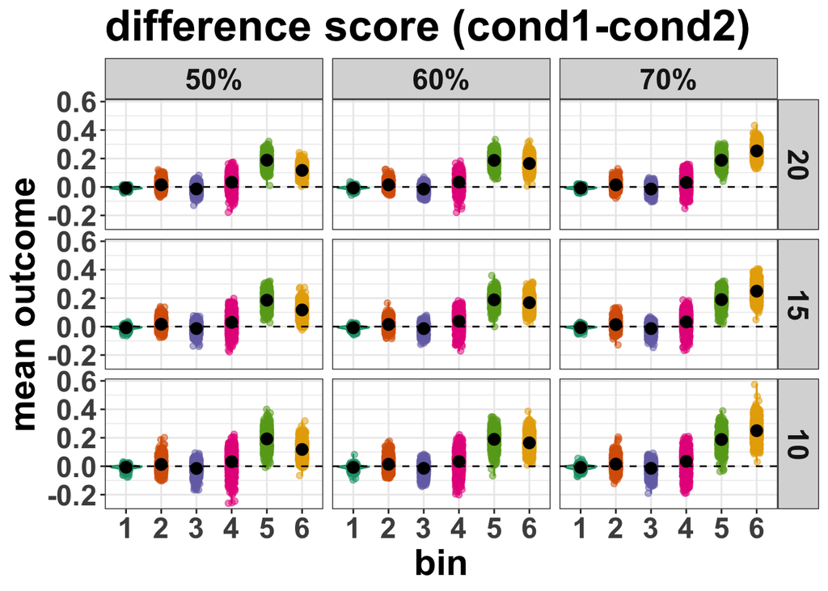

```r
p11.3 <- ggplot(sx2_diff_exp, aes(
  x = bin, y = exp_mean_diff,
  colour = bin, fill = bin
)) +
  geom_jitter(alpha = 0.5, width = 0.1) +
  geom_violin(alpha = 0.7) +
  geom_point(
    data = sx2_diff_sim,
    aes(y = mean_diff), size = 3, position = pd2, colour = "black"
  ) +
  geom_errorbar(
    data = sx2_diff_sim,
    aes(y = mean_diff, ymin = mean_diff - ci, ymax = mean_diff + ci),
    width = .2, position = pd2, colour = "black"
  ) +
  geom_hline(yintercept = 0, colour = "black", linetype = "dashed") +
  scale_fill_brewer(palette = "Dark2") +
  scale_colour_brewer(palette = "Dark2") +
  theme(legend.position = "none") +
  ylab("mean outcome") +
  ggtitle("difference score (cond1-cond2)") +
  facet_grid(fct_rev(subj_n) ~ b6c)
p11.3
```

```r
ggsave("Tutorial_4_planning/figures/sim2/sim_diffs.jpeg",
  width = 10, height = 8, dpi = 800
)
```

plot each exp’s difference score and associated 95% interval

create some factors and new variables

```r
sx2_diff_exp_2 <- sx2_diff_exp |>
  group_by(exp, subj_n, rep_n, b6c, bin) |>
  mutate(
    lower = exp_mean_diff - exp_ci,
    upper = exp_mean_diff + exp_ci,
    above_zero = if_else(lower > 0, "yes", "no"),
    above_zero = factor(above_zero, levels = c("no", "yes"))
  )
sx2_diff_exp_2
```

```
## # A tibble: 54,000 × 14
## # Groups:   exp, subj_n, rep_n, b6c, bin [54,000]
##    exp   subj_n rep_n b6c   bin   exp_mean_diff exp_sd     n exp_sem  exp_ci
##    <fct> <fct>  <fct> <fct> <fct>         <dbl>  <dbl> <int>   <dbl>   <dbl>
##  1 1     10     200   50%   1           0.00100 0.0165    10 0.00521 0.0102
##  2 1     10     200   50%   2           0.00386 0.0777    10 0.0246  0.0482
##  3 1     10     200   50%   3          -0.0676  0.108     10 0.0342  0.0671
##  4 1     10     200   50%   4          -0.0189  0.258     10 0.0816  0.160
##  5 1     10     200   50%   5           0.221   0.184     10 0.0580  0.114
##  6 1     10     200   50%   6           0.163   0.176     10 0.0558  0.109
##  7 1     10     200   60%   1          -0.006   0.0156    10 0.00493 0.00967
##  8 1     10     200   60%   2          -0.0135  0.0560    10 0.0177  0.0347
##  9 1     10     200   60%   3           0.0214  0.0878    10 0.0278  0.0544
## 10 1     10     200   60%   4          -0.00657 0.220     10 0.0696  0.136
## # ℹ 53,990 more rows
## # ℹ 4 more variables: exp_dz <dbl>, lower <dbl>, upper <dbl>, above_zero <fct>
```

calculate “power” in a quick and dirty way based on 95% CI

```r
power_x2 <- sx2_diff_exp_2 |>
  group_by(subj_n, rep_n, b6c, bin) |>
  mutate(check = ifelse(lower > 0, 1, 0)) |>
  summarise(power = mean(check, na.rm = TRUE)) |>
  filter(bin %in% c(6))
power_x2
```

```
## # A tibble: 9 × 5
## # Groups:   subj_n, rep_n, b6c [9]
##   subj_n rep_n b6c   bin   power
##   <fct>  <fct> <fct> <fct> <dbl>
## 1 10     200   50%   6     0.682
## 2 10     200   60%   6     0.869
## 3 10     200   70%   6     0.983
## 4 15     200   50%   6     0.831
## 5 15     200   60%   6     0.956
## 6 15     200   70%   6     0.997
## 7 20     200   50%   6     0.932
## 8 20     200   60%   6     0.986
## 9 20     200   70%   6     0.999
```

plot power

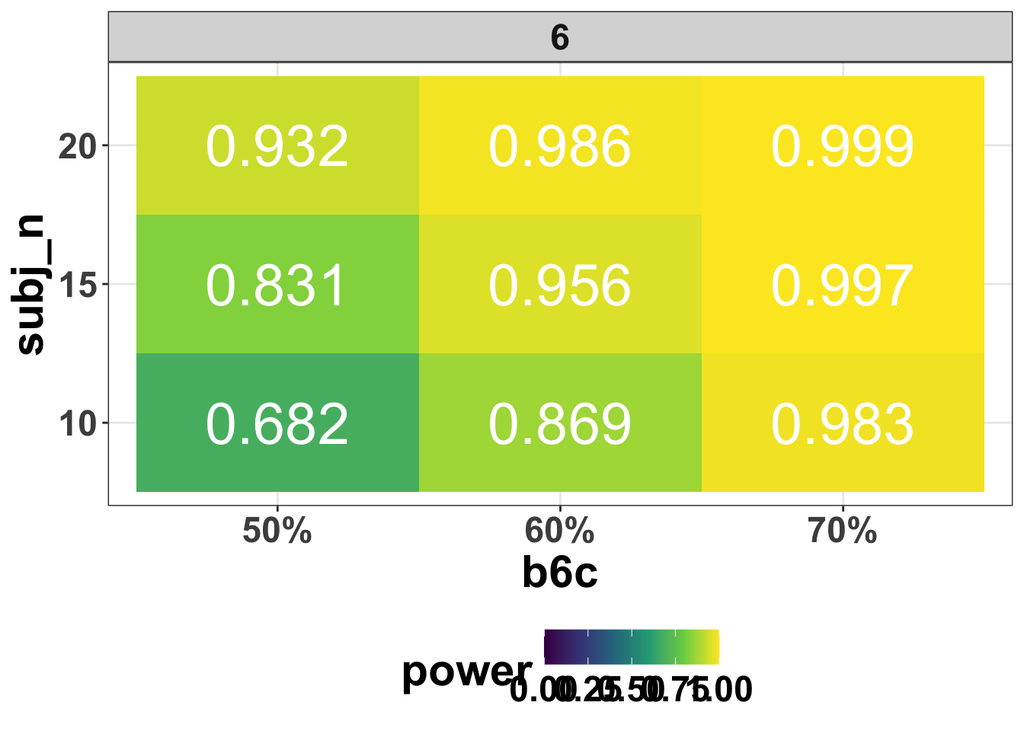

```r
p11.4 <- ggplot(power_x2, aes(x = b6c, y = subj_n, fill = power)) +
  geom_tile() +
  geom_text(aes(label = sprintf("%.3f", power)), color = "white", size = 10) +
  scale_fill_viridis_c(limits = c(0, 1)) +
  facet_wrap(~bin) +
  labs(y = "subj_n", x = "b6c")
p11.4
```

```r
#
ggsave("Tutorial_4_planning/figures/sim2/power.jpeg",
  width = 10, height = 6, dpi = 800
)
```

join power to the df

```r
sx2_diff_power <- sx2_diff_exp_2 |>
  filter(bin %in% c(6)) |>
  inner_join(power_x2, by = c("subj_n", "rep_n", "b6c", "bin")) |>
  mutate(power = round(power * 100, 2))
head(sx2_diff_power)
```

```
## # A tibble: 6 × 15
## # Groups:   exp, subj_n, rep_n, b6c, bin [6]
##   exp   subj_n rep_n b6c   bin   exp_mean_diff exp_sd     n exp_sem exp_ci
##   <fct> <fct>  <fct> <fct> <fct>         <dbl>  <dbl> <int>   <dbl>  <dbl>
## 1 1     10     200   50%   6            0.163  0.176     10  0.0558 0.109
## 2 1     10     200   60%   6            0.176  0.138     10  0.0435 0.0853
## 3 1     10     200   70%   6            0.295  0.221     10  0.0698 0.137
## 4 1     15     200   50%   6            0.0716 0.0938    15  0.0242 0.0475
## 5 1     15     200   60%   6            0.106  0.135     15  0.0348 0.0683
## 6 1     15     200   70%   6            0.204  0.155     15  0.0401 0.0785
## # ℹ 5 more variables: exp_dz <dbl>, lower <dbl>, upper <dbl>, above_zero <fct>,
## #   power <dbl>
```

plot

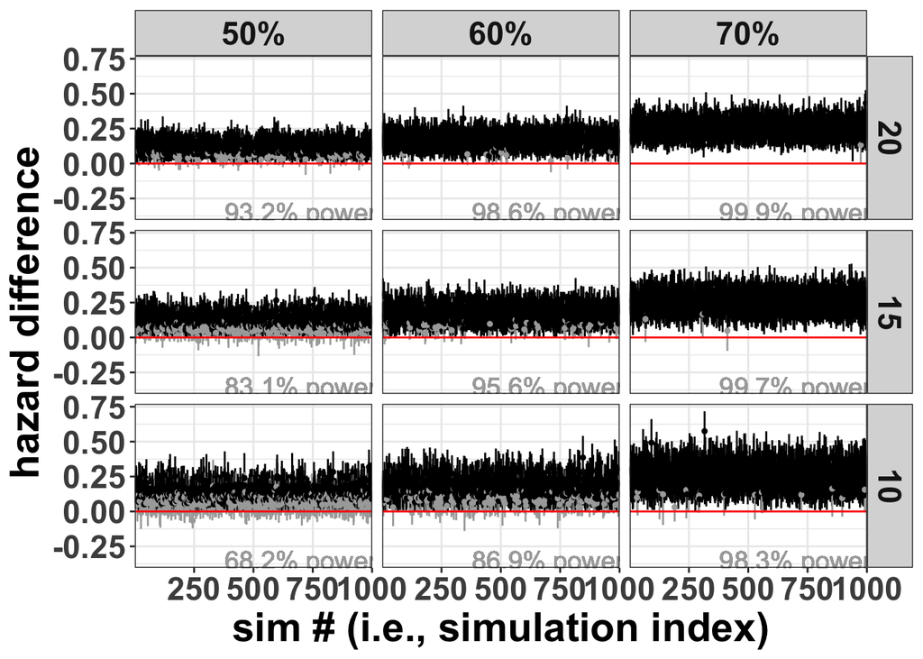

```r
p11.5 <- sx2_diff_power |>
  ggplot(aes(x = exp, y = exp_mean_diff, ymin = lower, ymax = upper)) +
  geom_pointrange(fatten = 1 / 2, aes(colour = above_zero)) +
  geom_hline(yintercept = 0, colour = "red") +
  scale_colour_manual(values = c("darkgrey", "black")) +
  geom_text(aes(x = 700, y = -0.35, label = sprintf("%.1f%s", power, "% power")),
    color = "darkgrey", size = 5
  ) +
  theme(legend.position = "none") +
  labs(
    x = "sim # (i.e., simulation index)",
    y = "hazard difference"
  ) +
  scale_x_discrete(breaks = c(250, 500, 750, 1000)) +
  facet_grid(fct_rev(subj_n) ~ b6c)
p11.5
```

```r
ggsave("Tutorial_4_planning/figures/sim2/bin6_diffs.jpeg",
  width = 10, height = 8, dpi = 800
)
```

plot power as a bar plot

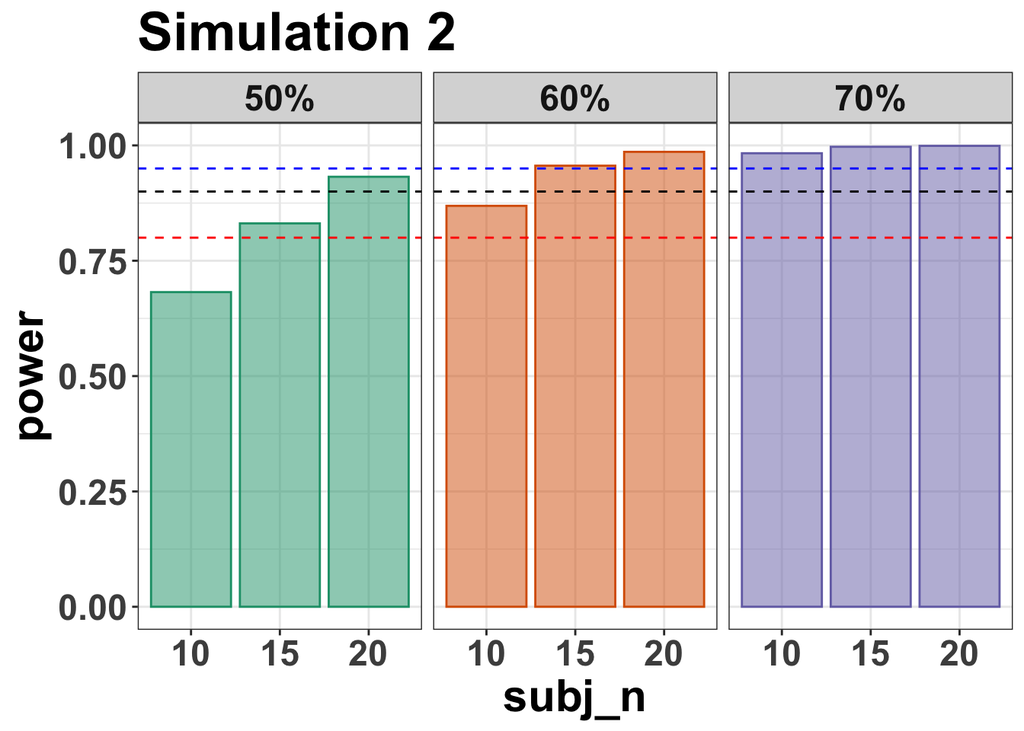

```r
p11.6 <- ggplot(power_x2, aes(
  x = subj_n, y = power,
  colour = b6c, fill = b6c
)) +
  geom_col(alpha = 0.5) +
  geom_hline(yintercept = 0.8, colour = "red", linetype = "dashed") +
  geom_hline(yintercept = 0.9, colour = "black", linetype = "dashed") +
  geom_hline(yintercept = 0.95, colour = "blue", linetype = "dashed") +
  scale_colour_brewer(palette = "Dark2") +
  scale_fill_brewer(palette = "Dark2") +
  labs(title = "Simulation 2") +
  theme(legend.position = "none") +
  facet_wrap(~b6c, nrow = 1)
p11.6
```

```r
ggsave("Tutorial_4_planning/figures/sim2/bin6_power_col.jpeg",
  width = 8, height = 6, dpi = 800
)
```

A summary of these power calculations might be as follows:

For a 70% reduction (0.3 hazard ratio), N=10, trial=200 per condition, would give nearly 100% power. For a 60% reduction (0.4 hazard ratio), N=10, trial=200 per condition, would give nearly 90% power. For a 50% reduction (0.5 hazard ratio), N=15, trial=200 per condition, would give over 80% power.

And a conclusion / judgment / decision process might be:

Well, like almost always, it depends on your objectives. Some considerations might be…

How much power or precision are you looking to obtain in this particular study? Are you running multiple studies that have some form of replication built in? What resources do you have at your disposal, such as time, money and personnel? How easy or difficult is it to obtain the specific type of sample?

My thoughts for studies in my lab might be something like this…

Pick 0.4 or 0.5 as a target effect size since this is much smaller than that observed in published studies, then pick the corresponding N value (i.e., N=10 or N=15) that takes you over the 80% power mark.

**But**, and this is an important “but”, do not solely rely on one study. Run a follow-up experiment that replicates and extends the initial result. By doing so, you avoid the Cult of the Isolated Single Study, and it reduces the reliance on any one type of power analysis. Instead, you are aiming for common patterns across two or more experiments, rather than trying to make the case that a single study has sufficient evidential value to hit some criterion mark.

# 12. Join some plots together

Join the power column plots together from sim1 and sim2.

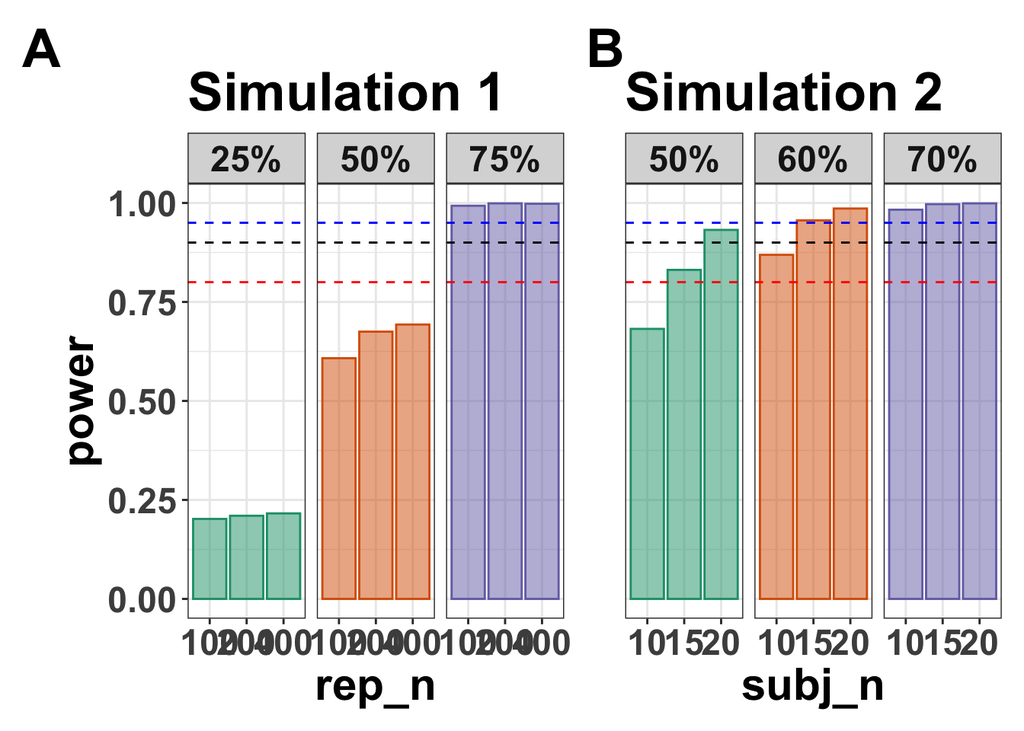

```r
p12.1 <- (p10.4 | p11.6) +
  plot_annotation(tag_levels = "A") +
  plot_layout(axes = "collect")
p12.1
```

```r
ggsave("Tutorial_4_planning/figures/bin6_power_col.jpeg",
  width = 12, height = 7, dpi = 800
)
```